# Importing Dataset

```python
import pandas as pd
import numpy as np
import matplotlib.pyplot as plt
import seaborn as sns
music = pd.read_csv("data/music_and_mental_health.csv")
```

```python
music.head()
```

|  | Timestamp | Age | Primary streaming service | Hours per day | While working | Instrumentalist | Composer | Fav genre | Exploratory | Foreign languages | ... | Frequency [R&B] | Frequency [Rap] | Frequency [Rock] | Frequency [Video game music] | Anxiety | Depression | Insomnia | OCD | Music effects | Permissions |
| --- | --- | --- | --- | --- | --- | --- | --- | --- | --- | --- | --- | --- | --- | --- | --- | --- | --- | --- | --- | --- | --- |
| 0 | 8/27/2022 19:29:02 | 18.0 | Spotify | 3.0 | Yes | Yes | Yes | Latin | Yes | Yes | ... | Sometimes | Very frequently | Never | Sometimes | 3.0 | 0.0 | 1.0 | 0.0 | NaN | I understand. |
| 1 | 8/27/2022 19:57:31 | 63.0 | Pandora | 1.5 | Yes | No | No | Rock | Yes | No | ... | Sometimes | Rarely | Very frequently | Rarely | 7.0 | 2.0 | 2.0 | 1.0 | NaN | I understand. |
| 2 | 8/27/2022 21:28:18 | 18.0 | Spotify | 4.0 | No | No | No | Video game music | No | Yes | ... | Never | Rarely | Rarely | Very frequently | 7.0 | 7.0 | 10.0 | 2.0 | No effect | I understand. |
| 3 | 8/27/2022 21:40:40 | 61.0 | YouTube Music | 2.5 | Yes | No | Yes | Jazz | Yes | Yes | ... | Sometimes | Never | Never | Never | 9.0 | 7.0 | 3.0 | 3.0 | Improve | I understand. |
| 4 | 8/27/2022 21:54:47 | 18.0 | Spotify | 4.0 | Yes | No | No | R&B | Yes | No | ... | Very frequently | Very frequently | Never | Rarely | 7.0 | 2.0 | 5.0 | 9.0 | Improve | I understand. |

5 rows × 33 columns

```python
music.info()
```

```
<class 'pandas.core.frame.DataFrame'>
RangeIndex: 736 entries, 0 to 735
Data columns (total 33 columns):
 #   Column                        Non-Null Count  Dtype
---  ------                        --------------  -----
 0   Timestamp                     736 non-null    object
 1   Age                           735 non-null    float64
 2   Primary streaming service     735 non-null    object
 3   Hours per day                 736 non-null    float64
 4   While working                 733 non-null    object
 5   Instrumentalist               732 non-null    object
 6   Composer                      735 non-null    object
 7   Fav genre                     736 non-null    object
 8   Exploratory                   736 non-null    object
 9   Foreign languages             732 non-null    object
```

[output cut: 25 more lines]

```python
music.describe()
```

|  | Age | Hours per day | BPM | Anxiety | Depression | Insomnia | OCD |
| --- | --- | --- | --- | --- | --- | --- | --- |
| count | 735.000000 | 736.000000 | 6.290000e+02 | 736.000000 | 736.000000 | 736.000000 | 736.000000 |
| mean | 25.206803 | 3.572758 | 1.589948e+06 | 5.837636 | 4.796196 | 3.738451 | 2.637228 |
| std | 12.054970 | 3.028199 | 3.987261e+07 | 2.793054 | 3.028870 | 3.088689 | 2.842017 |
| min | 10.000000 | 0.000000 | 0.000000e+00 | 0.000000 | 0.000000 | 0.000000 | 0.000000 |
| 25% | 18.000000 | 2.000000 | 1.000000e+02 | 4.000000 | 2.000000 | 1.000000 | 0.000000 |
| 50% | 21.000000 | 3.000000 | 1.200000e+02 | 6.000000 | 5.000000 | 3.000000 | 2.000000 |
| 75% | 28.000000 | 5.000000 | 1.440000e+02 | 8.000000 | 7.000000 | 6.000000 | 5.000000 |
| max | 89.000000 | 24.000000 | 1.000000e+09 | 10.000000 | 10.000000 | 10.000000 | 10.000000 |

# Checking Dataset

```python
music.shape
```

```
(736, 33)
```

###### The dataset has 736 rows and 33 columns

### Datatypes of all the Fields

```python
music.dtypes
```

```
Timestamp                        object
Age                             float64
Primary streaming service        object
Hours per day                   float64
While working                    object
Instrumentalist                  object
Composer                         object
Fav genre                        object
Exploratory                      object
Foreign languages                object
BPM                             float64
Frequency [Classical]            object
Frequency [Country]              object
Frequency [EDM]                  object
Frequency [Folk]                 object
Frequency [Gospel]               object
Frequency [Hip hop]              object
Frequency [Jazz]                 object
Frequency [K pop]                object
Frequency [Latin]                object
Frequency [Lofi]                 object
Frequency [Metal]                object
Frequency [Pop]                  object
Frequency [R&B]                  object
Frequency [Rap]                  object
Frequency [Rock]                 object
Frequency [Video game music]     object
Anxiety                         float64
Depression                      float64
Insomnia                        float64
OCD                             float64
Music effects                    object
Permissions                      object
dtype: object
```

### Information

```python
music.info()
```

```
<class 'pandas.core.frame.DataFrame'>
RangeIndex: 736 entries, 0 to 735
Data columns (total 33 columns):
 #   Column                        Non-Null Count  Dtype
---  ------                        --------------  -----
 0   Timestamp                     736 non-null    object
 1   Age                           735 non-null    float64
 2   Primary streaming service     735 non-null    object
 3   Hours per day                 736 non-null    float64
 4   While working                 733 non-null    object
 5   Instrumentalist               732 non-null    object
 6   Composer                      735 non-null    object
 7   Fav genre                     736 non-null    object
 8   Exploratory                   736 non-null    object
 9   Foreign languages             732 non-null    object
```

[output cut: 25 more lines]

###### This dataset has 33 columns.

###### Out of 33 columns 26 columns are Object type and rest are Numeric type.

### General Statistics

```python
music.describe()
```

|  | Age | Hours per day | BPM | Anxiety | Depression | Insomnia | OCD |
| --- | --- | --- | --- | --- | --- | --- | --- |
| count | 735.000000 | 736.000000 | 6.290000e+02 | 736.000000 | 736.000000 | 736.000000 | 736.000000 |
| mean | 25.206803 | 3.572758 | 1.589948e+06 | 5.837636 | 4.796196 | 3.738451 | 2.637228 |
| std | 12.054970 | 3.028199 | 3.987261e+07 | 2.793054 | 3.028870 | 3.088689 | 2.842017 |
| min | 10.000000 | 0.000000 | 0.000000e+00 | 0.000000 | 0.000000 | 0.000000 | 0.000000 |
| 25% | 18.000000 | 2.000000 | 1.000000e+02 | 4.000000 | 2.000000 | 1.000000 | 0.000000 |
| 50% | 21.000000 | 3.000000 | 1.200000e+02 | 6.000000 | 5.000000 | 3.000000 | 2.000000 |
| 75% | 28.000000 | 5.000000 | 1.440000e+02 | 8.000000 | 7.000000 | 6.000000 | 5.000000 |
| max | 89.000000 | 24.000000 | 1.000000e+09 | 10.000000 | 10.000000 | 10.000000 | 10.000000 |

###### The range of music listeners are from age 10 to 89.

###### Till 2nd quartile the values are quite relatable. Their is a big differene between 3rd quartile and max values of Age, Hours per day, and BPM. This shows it has outliers.

```python
music.describe(exclude='number').T
```

|  | count | unique | top | freq |
| --- | --- | --- | --- | --- |
| Timestamp | 736 | 735 | 8/28/2022 16:15:08 | 2 |
| Primary streaming service | 735 | 6 | Spotify | 458 |
| While working | 733 | 2 | Yes | 579 |
| Instrumentalist | 732 | 2 | No | 497 |
| Composer | 735 | 2 | No | 609 |
| Fav genre | 736 | 16 | Rock | 188 |
| Exploratory | 736 | 2 | Yes | 525 |
| Foreign languages | 732 | 2 | Yes | 404 |
| Frequency [Classical] | 736 | 4 | Rarely | 259 |
| Frequency [Country] | 736 | 4 | Never | 343 |
| Frequency [EDM] | 736 | 4 | Never | 307 |
| Frequency [Folk] | 736 | 4 | Never | 292 |
| Frequency [Gospel] | 736 | 4 | Never | 535 |
| Frequency [Hip hop] | 736 | 4 | Sometimes | 218 |
| Frequency [Jazz] | 736 | 4 | Never | 261 |
| Frequency [K pop] | 736 | 4 | Never | 416 |
| Frequency [Latin] | 736 | 4 | Never | 443 |
| Frequency [Lofi] | 736 | 4 | Never | 280 |
| Frequency [Metal] | 736 | 4 | Never | 264 |
| Frequency [Pop] | 736 | 4 | Very frequently | 277 |
| Frequency [R&B] | 736 | 4 | Never | 225 |
| Frequency [Rap] | 736 | 4 | Rarely | 215 |
| Frequency [Rock] | 736 | 4 | Very frequently | 330 |
| Frequency [Video game music] | 736 | 4 | Never | 236 |
| Music effects | 728 | 3 | Improve | 542 |
| Permissions | 736 | 1 | I understand. | 736 |

###### The result’s index includes count, unique, top, and freq. The top is the most common value. The freq is the most common value’s frequency.

###### It can be seen that the Timestamp column has a lot of unique values whereas Permission column has only one unique value.

# Understanding Correlation

### If there is correlation exists

##### The corr() method finds the correlation of each column in a DataFrame.

```python
data = music.corr()['Age']
data.sort_values(ascending=False)
```

```
Age              1.000000
Insomnia         0.006909
BPM             -0.029928
Hours per day   -0.044638
Depression      -0.121563
OCD             -0.130114
Anxiety         -0.176662
Name: Age, dtype: float64
```

[figure not shown]

```python
sns.heatmap(music.corr(), cmap = "YlGnBu")
```

# Cleaning Data

###### Checking for null values

```python
music.isna().sum()
```

```
Timestamp                         0
Age                               1
Primary streaming service         1
Hours per day                     0
While working                     3
Instrumentalist                   4
Composer                          1
Fav genre                         0
Exploratory                       0
Foreign languages                 4
BPM                             107
Frequency [Classical]             0
Frequency [Country]               0
Frequency [EDM]                   0
Frequency [Folk]                  0
Frequency [Gospel]                0
Frequency [Hip hop]               0
Frequency [Jazz]                  0
Frequency [K pop]                 0
Frequency [Latin]                 0
Frequency [Lofi]                  0
Frequency [Metal]                 0
Frequency [Pop]                   0
Frequency [R&B]                   0
Frequency [Rap]                   0
Frequency [Rock]                  0
Frequency [Video game music]      0
Anxiety                           0
Depression                        0
Insomnia                          0
OCD                               0
Music effects                     8
Permissions                       0
dtype: int64
```

### Filling null values

```python
music['Age'] = music['Age'].fillna(round(music['Age'].mean(), 0))
music['Primary streaming service'] = music['Primary streaming service'].fillna(music['Primary streaming service'].mode()[0])
music['While working'] = music['While working'].fillna(music['While working'].mode()[0])
music['Instrumentalist'] = music['Instrumentalist'].fillna(music['Instrumentalist'].mode()[0])
music['Composer'] = music['Composer'].fillna(music['Composer'].mode()[0])
music['Foreign languages'] = music['Foreign languages'].fillna(music['Foreign languages'].mode()[0])
music['Music effects'] = music['Music effects'].fillna(music['Music effects'].mode()[0])
```

###### Filling null values in columns with mode of the given column.

```python
music.isnull().sum()
```

```
Timestamp                         0
Age                               0
Primary streaming service         0
Hours per day                     0
While working                     0
Instrumentalist                   0
Composer                          0
Fav genre                         0
Exploratory                       0
Foreign languages                 0
BPM                             107
Frequency [Classical]             0
Frequency [Country]               0
Frequency [EDM]                   0
Frequency [Folk]                  0
Frequency [Gospel]                0
Frequency [Hip hop]               0
Frequency [Jazz]                  0
Frequency [K pop]                 0
Frequency [Latin]                 0
Frequency [Lofi]                  0
Frequency [Metal]                 0
Frequency [Pop]                   0
Frequency [R&B]                   0
Frequency [Rap]                   0
Frequency [Rock]                  0
Frequency [Video game music]      0
Anxiety                           0
Depression                        0
Insomnia                          0
OCD                               0
Music effects                     0
Permissions                       0
dtype: int64
```

### Removing spaces from column name

```python
music.columns = music.columns.str.replace(' ', '_')
```

```python
music.columns
```

```
Index(['Timestamp', 'Age', 'Primary_streaming_service', 'Hours_per_day',
       'While_working', 'Instrumentalist', 'Composer', 'Fav_genre',
       'Exploratory', 'Foreign_languages', 'BPM', 'Frequency_[Classical]',
       'Frequency_[Country]', 'Frequency_[EDM]', 'Frequency_[Folk]',
       'Frequency_[Gospel]', 'Frequency_[Hip_hop]', 'Frequency_[Jazz]',
       'Frequency_[K_pop]', 'Frequency_[Latin]', 'Frequency_[Lofi]',
       'Frequency_[Metal]', 'Frequency_[Pop]', 'Frequency_[R&B]',
       'Frequency_[Rap]', 'Frequency_[Rock]', 'Frequency_[Video_game_music]',
       'Anxiety', 'Depression', 'Insomnia', 'OCD', 'Music_effects',
       'Permissions'],
      dtype='object')
```

```python
bpm_new = music[music['BPM'].isnull() == True]
bpm_new
```

|  | Timestamp | Age | Primary_streaming_service | Hours_per_day | While_working | Instrumentalist | Composer | Fav_genre | Exploratory | Foreign_languages | ... | Frequency_[R&B] | Frequency_[Rap] | Frequency_[Rock] | Frequency_[Video_game_music] | Anxiety | Depression | Insomnia | OCD | Music_effects | Permissions |
| --- | --- | --- | --- | --- | --- | --- | --- | --- | --- | --- | --- | --- | --- | --- | --- | --- | --- | --- | --- | --- | --- |
| 10 | 8/27/2022 22:51:15 | 18.0 | Spotify | 3.0 | Yes | Yes | No | Country | Yes | No | ... | Rarely | Never | Rarely | Never | 7.0 | 7.0 | 4.0 | 7.0 | No effect | I understand. |
| 12 | 8/27/2022 23:04:00 | 25.0 | Spotify | 3.0 | Yes | No | No | Hip hop | Yes | Yes | ... | Sometimes | Rarely | Rarely | Never | 9.0 | 3.0 | 2.0 | 7.0 | Improve | I understand. |
| 15 | 8/27/2022 23:19:52 | 17.0 | Spotify | 2.0 | No | No | No | Pop | Yes | Yes | ... | Rarely | Sometimes | Sometimes | Rarely | 7.0 | 5.0 | 4.0 | 1.0 | Worsen | I understand. |
| 30 | 8/28/2022 10:30:22 | 20.0 | Apple Music | 5.0 | Yes | Yes | No | Rock | Yes | Yes | ... | Sometimes | Sometimes | Very frequently | Rarely | 7.0 | 7.0 | 2.0 | 0.0 | Improve | I understand. |
| 32 | 8/28/2022 10:54:30 | 19.0 | Spotify | 6.0 | Yes | Yes | No | Metal | Yes | Yes | ... | Never | Never | Sometimes | Sometimes | 9.0 | 8.0 | 2.0 | 3.0 | Improve | I understand. |
| ... | ... | ... | ... | ... | ... | ... | ... | ... | ... | ... | ... | ... | ... | ... | ... | ... | ... | ... | ... | ... | ... |
| 688 | 9/24/2022 0:42:39 | 18.0 | Spotify | 4.0 | Yes | No | No | R&B | No | No | ... | Very frequently | Sometimes | Never | Never | 8.0 | 0.0 | 0.0 | 2.0 | No effect | I understand. |
| 700 | 10/3/2022 10:00:01 | 20.0 | YouTube Music | 1.0 | Yes | No | No | Pop | No | Yes | ... | Rarely | Sometimes | Rarely | Very frequently | 8.0 | 9.0 | 6.0 | 5.0 | Worsen | I understand. |
| 706 | 10/3/2022 15:38:19 | 23.0 | Spotify | 1.0 | Yes | Yes | No | Rock | Yes | Yes | ... | Sometimes | Sometimes | Very frequently | Very frequently | 8.0 | 6.0 | 1.0 | 4.0 | Improve | I understand. |
| 712 | 10/4/2022 8:53:39 | 23.0 | I do not use a streaming service. | 3.0 | Yes | No | No | Rock | No | No | ... | Rarely | Never | Very frequently | Never | 10.0 | 5.0 | 2.0 | 0.0 | Improve | I understand. |
| 717 | 10/5/2022 12:30:23 | 23.0 | Spotify | 2.0 | No | No | No | Rock | Yes | Yes | ... | Sometimes | Sometimes | Very frequently | Never | 5.0 | 7.0 | 10.0 | 2.0 | No effect | I understand. |

107 rows × 33 columns

```python
music[music['BPM'].isna()]
```

|  | Timestamp | Age | Primary_streaming_service | Hours_per_day | While_working | Instrumentalist | Composer | Fav_genre | Exploratory | Foreign_languages | ... | Frequency_[R&B] | Frequency_[Rap] | Frequency_[Rock] | Frequency_[Video_game_music] | Anxiety | Depression | Insomnia | OCD | Music_effects | Permissions |
| --- | --- | --- | --- | --- | --- | --- | --- | --- | --- | --- | --- | --- | --- | --- | --- | --- | --- | --- | --- | --- | --- |
| 10 | 8/27/2022 22:51:15 | 18.0 | Spotify | 3.0 | Yes | Yes | No | Country | Yes | No | ... | Rarely | Never | Rarely | Never | 7.0 | 7.0 | 4.0 | 7.0 | No effect | I understand. |
| 12 | 8/27/2022 23:04:00 | 25.0 | Spotify | 3.0 | Yes | No | No | Hip hop | Yes | Yes | ... | Sometimes | Rarely | Rarely | Never | 9.0 | 3.0 | 2.0 | 7.0 | Improve | I understand. |
| 15 | 8/27/2022 23:19:52 | 17.0 | Spotify | 2.0 | No | No | No | Pop | Yes | Yes | ... | Rarely | Sometimes | Sometimes | Rarely | 7.0 | 5.0 | 4.0 | 1.0 | Worsen | I understand. |
| 30 | 8/28/2022 10:30:22 | 20.0 | Apple Music | 5.0 | Yes | Yes | No | Rock | Yes | Yes | ... | Sometimes | Sometimes | Very frequently | Rarely | 7.0 | 7.0 | 2.0 | 0.0 | Improve | I understand. |
| 32 | 8/28/2022 10:54:30 | 19.0 | Spotify | 6.0 | Yes | Yes | No | Metal | Yes | Yes | ... | Never | Never | Sometimes | Sometimes | 9.0 | 8.0 | 2.0 | 3.0 | Improve | I understand. |
| ... | ... | ... | ... | ... | ... | ... | ... | ... | ... | ... | ... | ... | ... | ... | ... | ... | ... | ... | ... | ... | ... |
| 688 | 9/24/2022 0:42:39 | 18.0 | Spotify | 4.0 | Yes | No | No | R&B | No | No | ... | Very frequently | Sometimes | Never | Never | 8.0 | 0.0 | 0.0 | 2.0 | No effect | I understand. |
| 700 | 10/3/2022 10:00:01 | 20.0 | YouTube Music | 1.0 | Yes | No | No | Pop | No | Yes | ... | Rarely | Sometimes | Rarely | Very frequently | 8.0 | 9.0 | 6.0 | 5.0 | Worsen | I understand. |
| 706 | 10/3/2022 15:38:19 | 23.0 | Spotify | 1.0 | Yes | Yes | No | Rock | Yes | Yes | ... | Sometimes | Sometimes | Very frequently | Very frequently | 8.0 | 6.0 | 1.0 | 4.0 | Improve | I understand. |
| 712 | 10/4/2022 8:53:39 | 23.0 | I do not use a streaming service. | 3.0 | Yes | No | No | Rock | No | No | ... | Rarely | Never | Very frequently | Never | 10.0 | 5.0 | 2.0 | 0.0 | Improve | I understand. |
| 717 | 10/5/2022 12:30:23 | 23.0 | Spotify | 2.0 | No | No | No | Rock | Yes | Yes | ... | Sometimes | Sometimes | Very frequently | Never | 5.0 | 7.0 | 10.0 | 2.0 | No effect | I understand. |

107 rows × 33 columns

```python
bpm_new['Fav_genre'].unique()
```

```
array(['Country', 'Hip hop', 'Pop', 'Rock', 'Metal', 'Classical',
       'Video game music', 'R&B', 'Folk', 'Jazz', 'EDM', 'Gospel',
       'K pop', 'Rap'], dtype=object)
```

```python
bpm_new_genre = ['Country', 'Hip hop', 'Pop', 'Rock', 'Metal', 'Classical',
       'Video game music', 'R&B', 'Folk', 'Jazz', 'EDM', 'Gospel',
       'K pop', 'Rap']
```

```python
for i in bpm_new_genre:
    music['BPM'] = music['BPM'].fillna(round(music[music['Fav_genre']== i ]['BPM'].mean(), 0))
```

```python
music.isna().sum()
```

```
Timestamp                       0
Age                             0
Primary_streaming_service       0
Hours_per_day                   0
While_working                   0
Instrumentalist                 0
Composer                        0
Fav_genre                       0
Exploratory                     0
Foreign_languages               0
BPM                             0
Frequency_[Classical]           0
Frequency_[Country]             0
Frequency_[EDM]                 0
Frequency_[Folk]                0
Frequency_[Gospel]              0
Frequency_[Hip_hop]             0
Frequency_[Jazz]                0
Frequency_[K_pop]               0
Frequency_[Latin]               0
Frequency_[Lofi]                0
Frequency_[Metal]               0
Frequency_[Pop]                 0
Frequency_[R&B]                 0
Frequency_[Rap]                 0
Frequency_[Rock]                0
Frequency_[Video_game_music]    0
Anxiety                         0
Depression                      0
Insomnia                        0
OCD                             0
Music_effects                   0
Permissions                     0
dtype: int64
```

### With this we had remove all the null values and completely cleans our data

# Data Visualization

### Looking at age distribution among participants

```
[Text(0.5, 1.0, 'Age Distribution of Participants')]
```

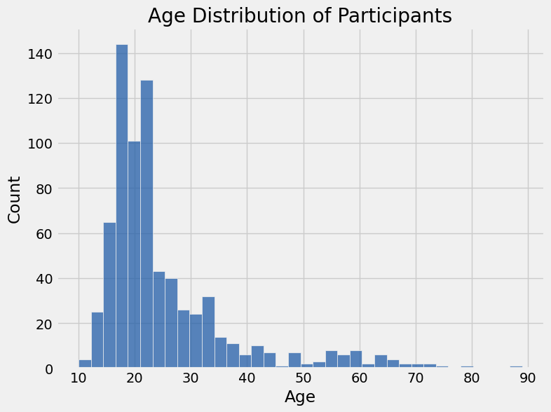

```python
plt.style.use('fivethirtyeight')
plt.figure(figsize=(8,6))
sns.histplot(music['Age'], color="#225ea8").set(title="Age Distribution of Participants")
```

```python
music['Age'].value_counts().loc[lambda x : x>50]
```

```
18.0    85
19.0    61
17.0    59
21.0    52
Name: Age, dtype: int64
```

```python
music['Age'].max()
```

```
89.0
```

###### It is very clear from the graph that people of age 16 - 24 are more frequently listening music. Most respondents are in their late teens or early twenties. A single 89 year old respondent is an interesting outlier!

###### The age distribution makes sense, as the survey used to collect data was advertised in discussion forums and social media sites that target this demographic. This may introduce age bias, i.e. influencing which music genres are most popular.

### Number of hours participants listened to music per day

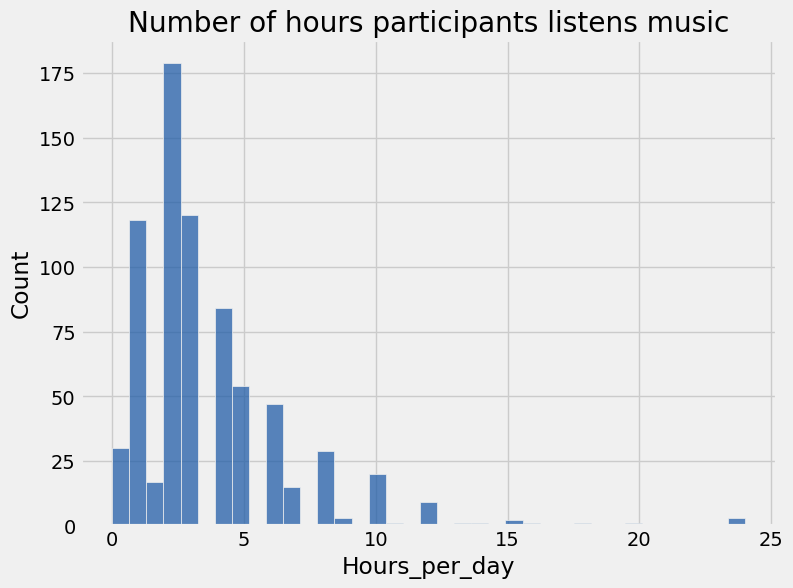

```python
plt.figure(figsize=(8,6))
sns.histplot(music['Hours_per_day'], color="#225ea8").set(title="Number of hours participants listens music")
plt.show()
```

```python
music['Hours_per_day'].value_counts().head(8)
```

```
2.0     173
3.0     120
1.0     117
4.0      83
5.0      54
6.0      47
8.0      29
10.0     20
Name: Hours_per_day, dtype: int64
```

###### The vast majority of respondents listen to music between 0-5 hours per day. After this threshold, the number of respondents that listen to music 5+ hours a day decreases almost exponentially.

###### Also there are a few respondents who claim to listen to music 24 hours a day.

### Number of Participants who listens music while working

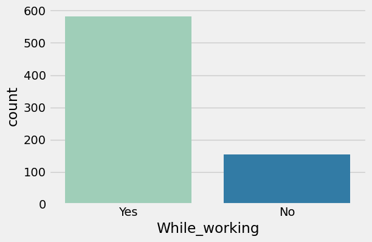

```python
plt.figure(figsize=(6,4))
sns.countplot(x=music['While_working'], palette="YlGnBu")
```

```python
music['While_working'].value_counts()
```

```
Yes    582
No     154
Name: While_working, dtype: int64
```

###### It is very clear from the plot is almost 80% of the people listens to music while they were working.

### Streming Services used by participants

```python
music['Primary_streaming_service'].value_counts()
```

```
Spotify                              459
YouTube Music                         94
I do not use a streaming service.     71
Apple Music                           51
Other streaming service               50
Pandora                               11
Name: Primary_streaming_service, dtype: int64
```

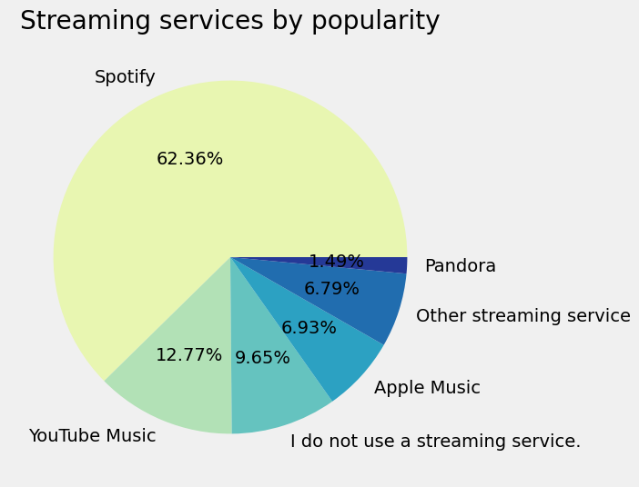

```python
plt.figure(figsize=(8,6))

services_used = music['Primary_streaming_service'].value_counts()
services_used.plot(kind='pie', colors = sns.color_palette('YlGnBu'), autopct="%1.2f%%")

plt.title('Streaming services by popularity', loc="center")
plt.ylabel("")
```

###### It is very evident that Spotify is the most used streaming service which grabs more than 50% of the audience.

```
(array([0, 1, 2, 3, 4, 5]),
 [Text(0, 0, 'Spotify'),
```

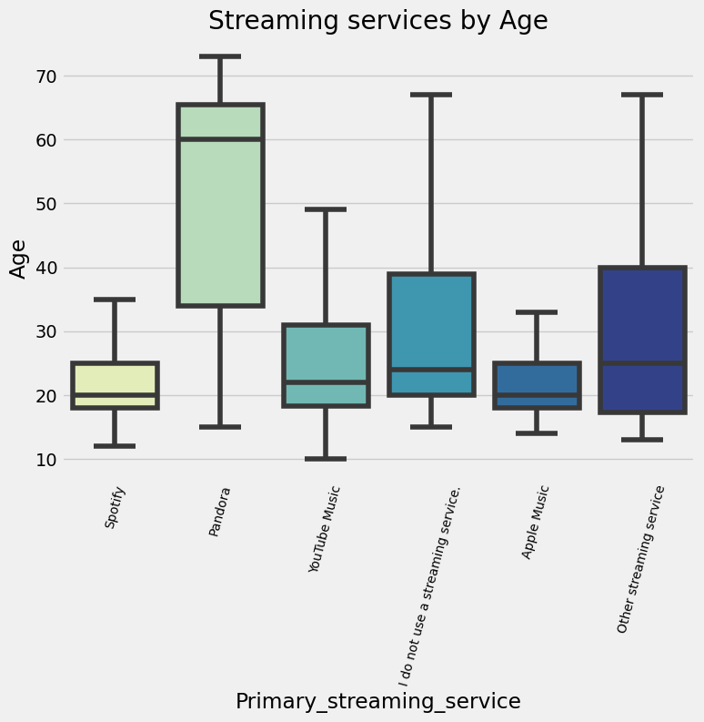

```python
plt.figure(figsize=(8,6))
servies_age = sns.boxplot(data=music, x="Primary_streaming_service", y = "Age",
            showfliers = False,
            palette = "YlGnBu")

plt.title('Streaming services by Age')
plt.xticks(size=10, rotation=75)
```

```python
df = music.groupby(['Primary_streaming_service'])
df
```

```
<pandas.core.groupby.generic.DataFrameGroupBy object at 0x000001C692756640>
```

```python
df_ages = []
df_ages
```

```
[]
```

```python
df['Age'].median()
```

```
Primary_streaming_service
Apple Music                          20.0
I do not use a streaming service.    24.0
Other streaming service              25.0
Pandora                              60.0
Spotify                              20.0
YouTube Music                        22.0
Name: Age, dtype: float64
```

```python
df_ages.append(df['Age'].median())
```

```python
df_ages
```

```
[Primary_streaming_service
 Apple Music                          20.0
 I do not use a streaming service.    24.0
 Other streaming service              25.0
 Pandora                              60.0
 Spotify                              20.0
 YouTube Music                        22.0
 Name: Age, dtype: float64]
```

###### Spotify is the most popular music streaming service, accounting for 62% of all respondents.

###### Spotify, along with Apple Music, also has a marginally younger userbase than other streaming platforms. Pandora has the oldest user base by far, with the median user age at ~60 years old.

### Musical Background

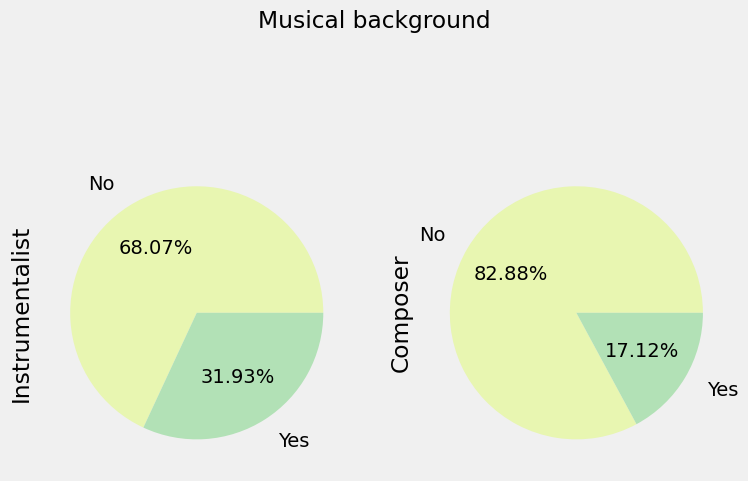

```python
fig = plt.figure(figsize=(8,6))
plt.suptitle("Musical background")
plt.subplot(1,2,1)
inst = music['Instrumentalist'].value_counts()
inst.plot(kind='pie', colors = sns.color_palette('YlGnBu'), labeldistance = 1.2, autopct="%1.2f%%")

plt.subplot(1,2,2)
comp = music['Composer'].value_counts()
comp.plot(kind='pie', colors = sns.color_palette('YlGnBu'), labeldistance = 1.2, autopct="%1.2f%%")
```

###### It is very evident that most of the respondents do not play an instrument. It is even rarer for a respondent to compose music.

## Genre Analysis

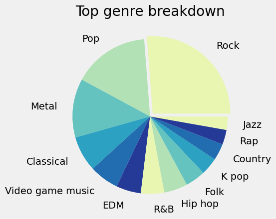

```python
genre = music["Fav_genre"].value_counts().loc[lambda x: x>10]
genre.plot(kind='pie', labeldistance = 1.2,
           explode=[0.05, 0, 0, 0, 0, 0, 0, 0, 0, 0, 0, 0, 0,],
           colors = sns.color_palette('YlGnBu')[0:13])

plt.title('Top genre breakdown')
plt.ylabel("")
```

#### Rock is the most popular genre, being selected as an individual's favorite genre 1 out of 4 times.

#### In terms of popularity, Rock is followed by Pop and Metal.

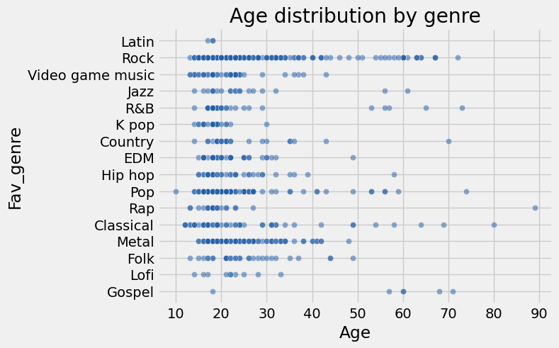

```python
sns.scatterplot(data=music, y="Fav_genre", x="Age", alpha = 0.5, color="#225ea8")
plt.title('Age distribution by genre');
```

#### Rock has the most diverse range of ages. Classical and Pop listeners also have a wider range of ages compared to other genres.

#### Some music genres, such as Video game music, K pop and Lofi appear to attract a more specific and younger age group.

### Bivariate Analysis

```
<function matplotlib.pyplot.show(close=None, block=None)>
```

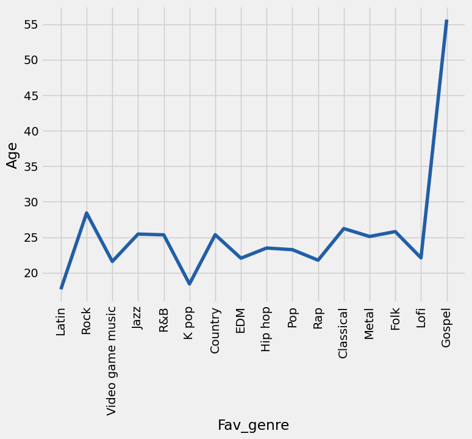

```python
plt.figure(figsize=(8,6))
sns.lineplot(x=music['Fav_genre'], y=music['Age'], ci=None, color="#225ea8")
plt.xticks(rotation=90)
plt.show
```

###### Gospel is more famous in people around age of 50 and above.

###### Besides these above mentioned genre are heard by people from age of 20 to 30.

```
<function matplotlib.pyplot.show(close=None, block=None)>
```

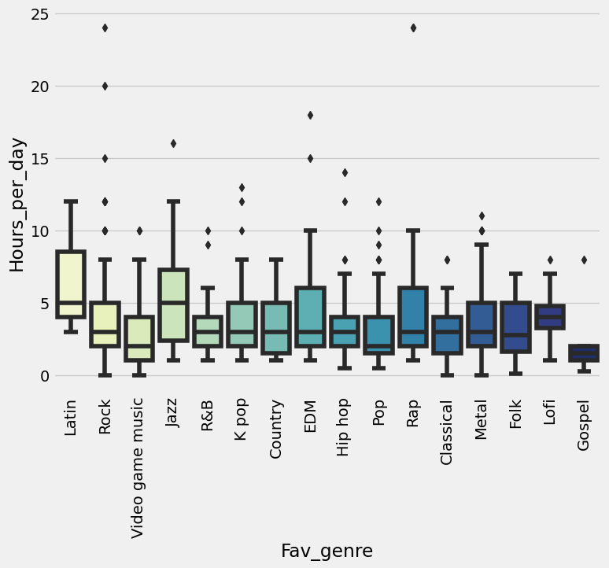

```python
plt.figure(figsize=(8,6))
sns.boxplot(x=music['Fav_genre'], y=music['Hours_per_day'], palette="YlGnBu")
plt.xticks(rotation=90)
plt.show
```

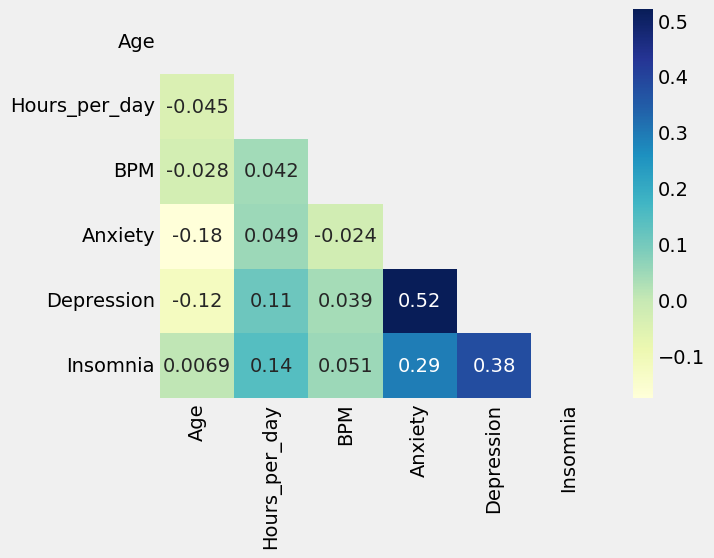

```python
corr_m = music.corr()
corr_m1 = corr_m.iloc[:-1,:-1]

mask = np.triu(corr_m1)

sns.heatmap(corr_m1, annot=True, mask=mask, cmap = "YlGnBu")
plt.show()
```

## With this we ended with general visualization of music related data.

## Data Visualization regarding Mental Health

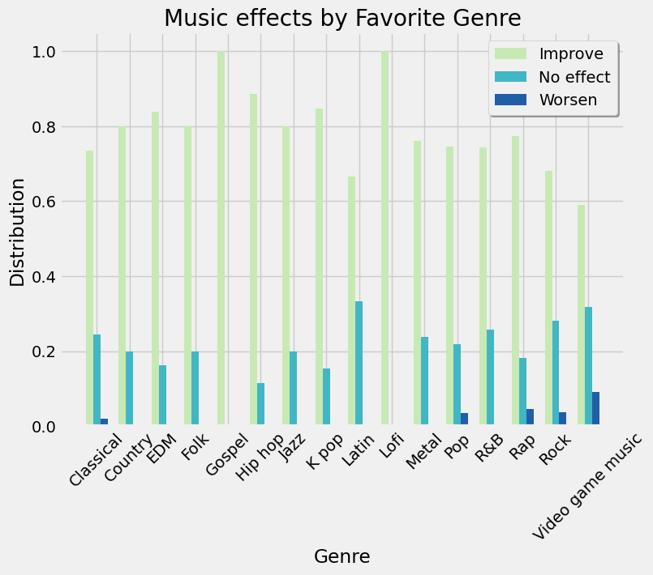

```python
g_all = music['Fav_genre'].unique()
g_all.sort()
fg_df = music.groupby(['Fav_genre'])
fg_dist = fg_df['Music_effects'].value_counts(ascending=False, normalize=True).tolist()

insert_indices = [5, 8, 11, 13, 14, 17, 20, 23, 26, 28, 29, 32, 38]
for i in range(len(insert_indices)):
    fg_dist.insert(insert_indices[i], 0)

imp_dist = fg_dist[0::3]
no_eff_dist = fg_dist[1::3]
wors_dist = fg_dist[2::3]

width = 0.22

x = np.arange(len(g_all))

fig, ax = plt.subplots(figsize=(8, 6))

b1 = ax.bar(x-width, imp_dist, width, label="Improve", color = '#c7e9b4')
b2 = ax.bar(x, no_eff_dist, width, label="No effect", color = '#41b6c4')
b3 = ax.bar(x+width, wors_dist, width, label="Worsen", color = '#225ea8')

plt.title("Music effects by Favorite Genre")
ax.set_ylabel('Distribution')
ax.set_xlabel('Genre')
ax.set_xticks(x, g_all, rotation = 45)
ax.legend(shadow="true")

plt.show()
```

#### Regardless of genre, the vast majority of respondents agree that music has a positive impact on mental health.

#### Individuals who selected Gospel and Lofi as their favorite genre unanimously find music beneficial.

#### Individuals who selected Video Game Music as their favorite genre have the most diverse distribution of responses. Roughly 40% of these respondents did not find music beneficial at all, with 10% of respondents reporting a negative impact on their mental health.

#### The only other respondents that found music detrimental were respondents who selected Classical, Pop, Rap, or Rock music as their top genre.

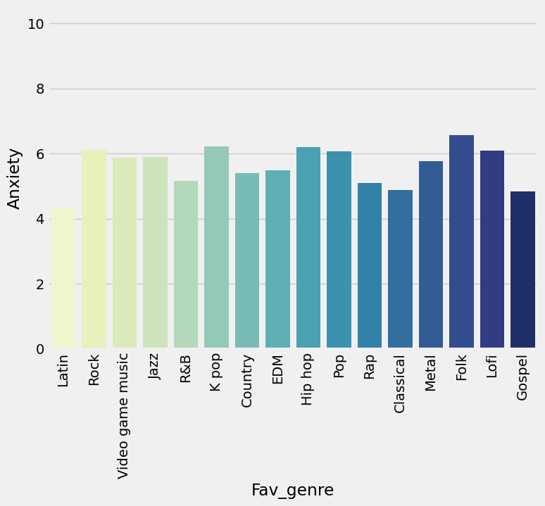

```python
plt.figure(figsize=(8,6))
sns.barplot(x=music['Fav_genre'], y=music['Anxiety'], errwidth=0, palette="YlGnBu")
plt.xticks(rotation=90)
plt.show()
```

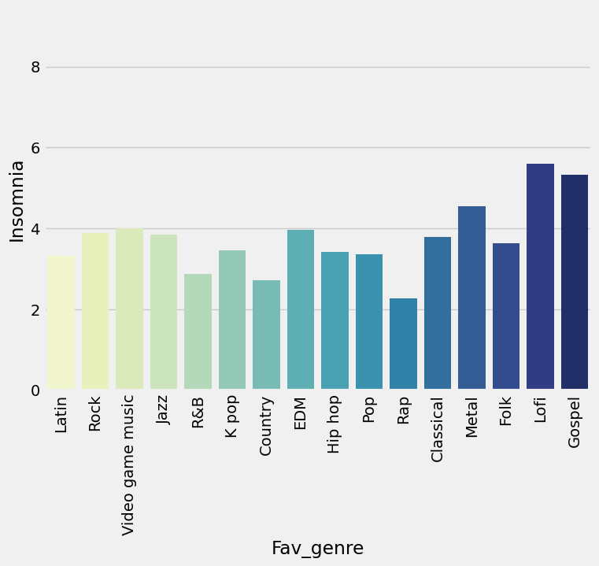

```python
plt.figure(figsize=(8,6))
sns.barplot(x=music['Fav_genre'], y=music['Insomnia'], errwidth=0, palette="YlGnBu")
plt.xticks(rotation=90)
plt.show()
```

#### Every listener have Insomnia level below 4. Only listeners listenting to Mental, Lofi and Gospel have level more than 4.

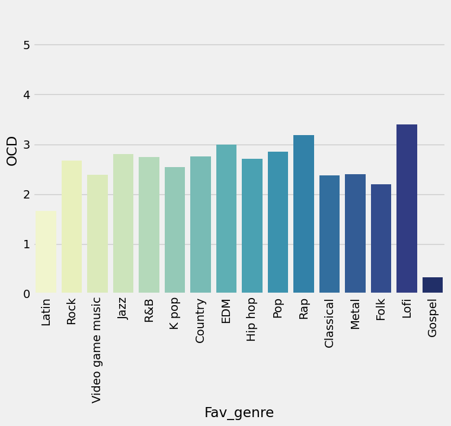

```python
plt.figure(figsize=(8,6))
sns.barplot(x=music['Fav_genre'], y=music['OCD'], errwidth=0, palette="YlGnBu")
plt.xticks(rotation=90)
plt.show()
```

#### Every listeners have OCD level less than 3. Only listeners listening to Rap and Lofi have level more than 3.

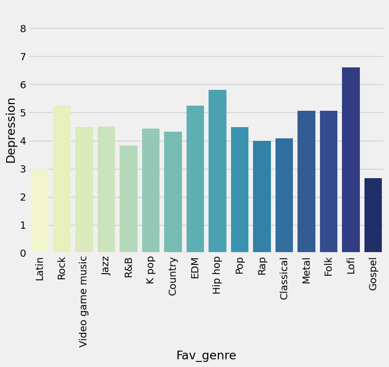

```python
plt.figure(figsize=(8,6))
sns.barplot(x=music['Fav_genre'], y=music['Depression'], errwidth=0, palette="YlGnBu")
plt.xticks(rotation=90)
plt.show()
```

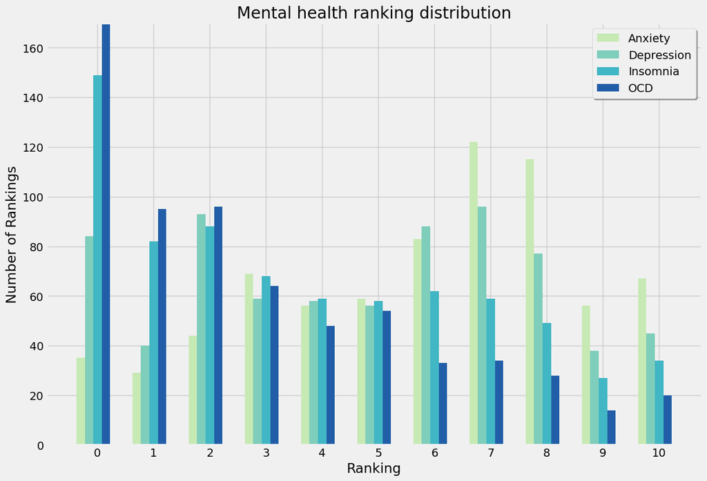

```python
m_all = ["Anxiety", "Depression", "Insomnia", "OCD"]

mental_music = music[m_all]
mental_music.round(0).astype(int)

disorder_count = []
for disorder in m_all:
    x=0
    while x !=11:
        count =  (mental_music[disorder].values == x).sum()
        disorder_count.append(count)
        x +=1

labels = ['0','1', '2', '3', '4', '5', '6', '7', '8', '9', '10']
x = np.arange(len(labels))
width = 0.15

fig, ax = plt.subplots(figsize=(13, 9))

b1 = ax.bar(x-2*width, disorder_count[0:11], width, label="Anxiety", color = '#c7e9b4')
b2 = ax.bar(x-width, disorder_count[11:22], width, label="Depression", color = '#7fcdbb')
b3 = ax.bar(x, disorder_count[22:33], width, label="Insomnia", color = '#41b6c4')
b4 = ax.bar(x+width, disorder_count[33:], width, label="OCD", color = '#225ea8')

ax.set_ylim([0, 170])
ax.set_ylabel('Number of Rankings')
ax.set_xlabel('Ranking')
ax.set_title('Mental health ranking distribution')
ax.set_xticks(x, labels)
ax.legend(shadow=True)

plt.show()
```

```python
max(disorder_count)
```

```
248
```

```python
for disorder in m_all:
    disorder_avg = str(round(music[disorder].mean(), 2))
    print(disorder + ' average: ' + disorder_avg)
```

```
Anxiety average: 5.84
Depression average: 4.8
Insomnia average: 3.74
OCD average: 2.64
```

#### Insomnia is somewhat common and distributed more fairly outside of the 0 ranking. However, insomnia rankings do demonstrate a downward trend in popularity as the rankings increase.

#### With 0 as its mode, OCD is the least common disorder. Similarly to the insomnia rankings, as OCD rankings increase, they tend to decrease in popularity.

## Listenting Time and Mental Health (MH)

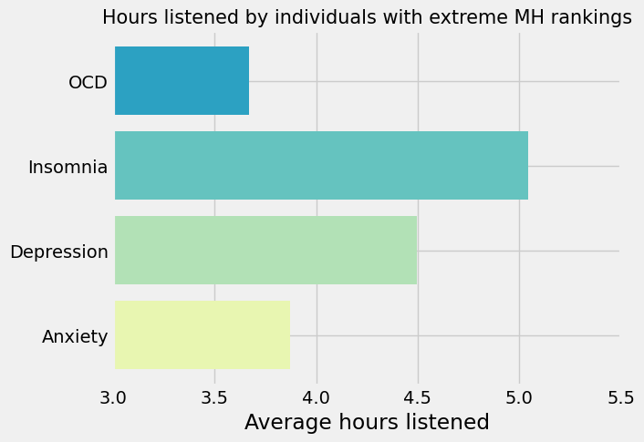

```python
anxiety_extreme = music.loc[(music['Anxiety'] > 8)].mean()[1]
depression_extreme = music.loc[(music['Depression'] > 8)].mean()[1]
insomnia_extreme = music.loc[(music['Insomnia'] > 8)].mean()[1]
ocd_extreme = music.loc[(music['OCD'] > 8)].mean()[1]

extreme_means = [anxiety_extreme, depression_extreme, insomnia_extreme, ocd_extreme]

plt.barh(m_all, extreme_means,color = sns.color_palette('YlGnBu'))

plt.xlabel("Average hours listened")
plt.title("Hours listened by individuals with extreme MH rankings", fontsize=15)
plt.xlim(3,5.5)
plt.show()
```

#### An extreme MH ranking is defined as a ranking of 9 or 10.

#### Extreme insomniacs rack up slightly more listening time compared to individuals with extreme rankings in other categories. Individuals with extreme OCD have a slightly lower listening time. However, these differences may be considered negligible.

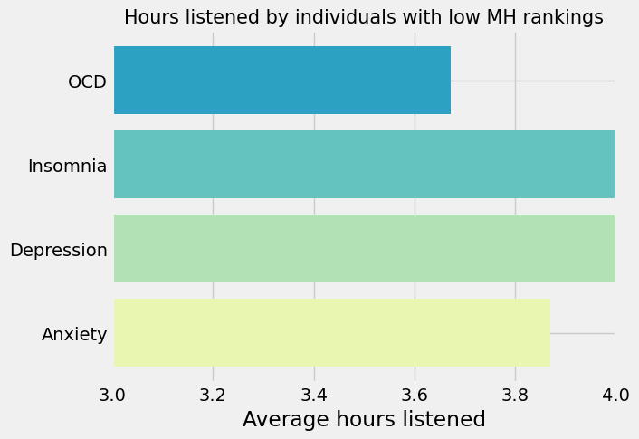

```python
anxiety_extreme2 = music.loc[(music['Anxiety'] < 3)].mean()[1]
depression_extreme2 = music.loc[(music['Depression'] < 3)].mean()[1]
insomnia_extreme2 = music.loc[(music['Insomnia'] < 3)].mean()[1]
ocd_extreme2 = music.loc[(music['OCD'] < 3)].mean()[1]

extreme_means = [anxiety_extreme, depression_extreme, insomnia_extreme, ocd_extreme]

plt.barh(m_all, extreme_means, color = sns.color_palette('YlGnBu'))

plt.xlabel("Average hours listened")
plt.title("Hours listened by individuals with low MH rankings", fontsize=15)
plt.xlim(3,4)
plt.show()
```

#### A low MH ranking is defined as a ranking of 0, 1, or 2.

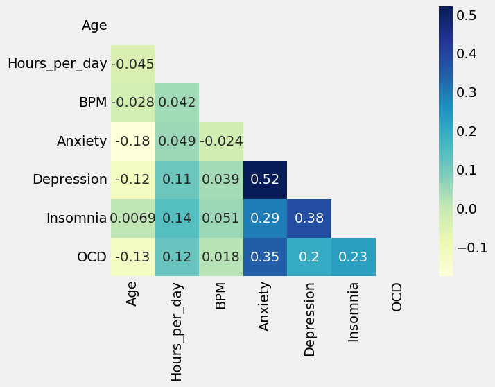

```python
corr_m = music.corr()
mask = np.triu(corr_m)

sns.heatmap(corr_m, annot=True, mask=mask, cmap = "YlGnBu")
plt.show()
```

```python
music.corr()
```

|  | Age | Hours_per_day | BPM | Anxiety | Depression | Insomnia | OCD |
| --- | --- | --- | --- | --- | --- | --- | --- |
| Age | 1.000000 | -0.044632 | -0.028208 | -0.176534 | -0.121520 | 0.006920 | -0.129940 |
| Hours_per_day | -0.044632 | 1.000000 | 0.041775 | 0.049319 | 0.110527 | 0.141821 | 0.118729 |
| BPM | -0.028208 | 0.041775 | 1.000000 | -0.024285 | 0.039042 | 0.050927 | 0.017699 |
| Anxiety | -0.176534 | 0.049319 | -0.024285 | 1.000000 | 0.519969 | 0.292669 | 0.348350 |
| Depression | -0.121520 | 0.110527 | 0.039042 | 0.519969 | 1.000000 | 0.378996 | 0.196988 |
| Insomnia | 0.006920 | 0.141821 | 0.050927 | 0.292669 | 0.378996 | 1.000000 | 0.226354 |
| OCD | -0.129940 | 0.118729 | 0.017699 | 0.348350 | 0.196988 | 0.226354 | 1.000000 |

#### All four disorders show significant overlap with each other, with depression and anxiety witnessing the strongest linear correlation. Depression and Insomnia also witness a strong correlation, same is the case with OCD and Anxiety.

#### OCD is somewhat related to the other categories, but the correlation matrix does not imply as strong of a relationship.

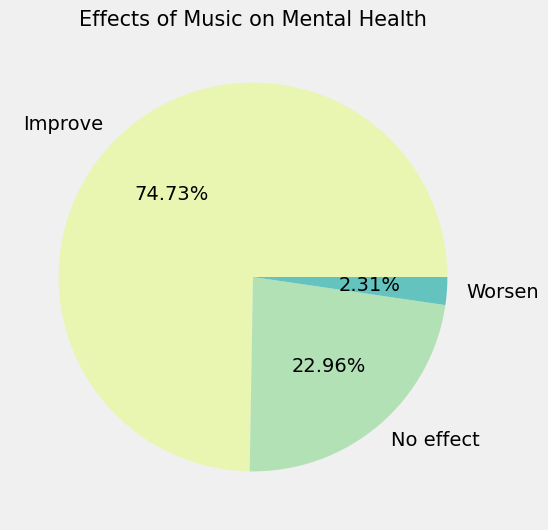

```python
plt.figure(figsize=(8,6))
plt.title('Effects of Music on Mental Health', fontsize=15)

effects = music['Music_effects'].value_counts()
effects.plot(kind='pie', colors = sns.color_palette('YlGnBu') , ylabel= '', autopct="%1.2f%%")
```

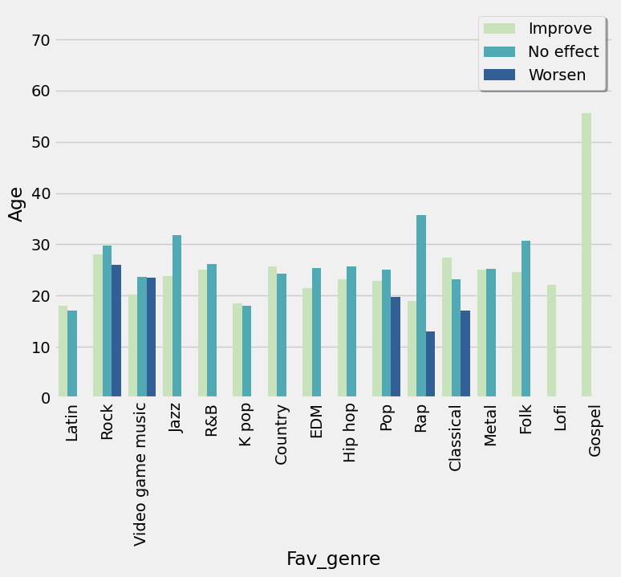

```python
plt.figure(figsize=(8,6))
sns.barplot(x=music['Fav_genre'], y=music['Age'], hue=music['Music_effects'], errwidth=0, palette='YlGnBu')
plt.xticks(rotation=90)
plt.legend(shadow=True, loc='upper right')
plt.show()
```

#### Every Music listeners of every age showing some kind of improvement but Rock, Video Game Music, Pop, Rap, and Classical have worsen mental health condition of listeners.

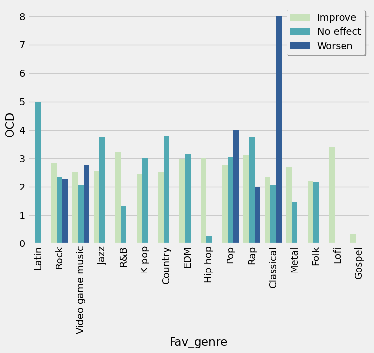

```python
plt.figure(figsize=(8,6))
sns.barplot(x=music['Fav_genre'], y=music['OCD'], hue=music['Music_effects'], errwidth=0, palette='YlGnBu')
plt.xticks(rotation=90)
plt.legend(shadow=True, loc='upper right')
plt.show()
```

#### There is not much improvement in case of OCD.

#### Rock, Video Game music, Pop, Rap have negative impact on mental health of listeners. Classical music have worsen the mental health of listeners.

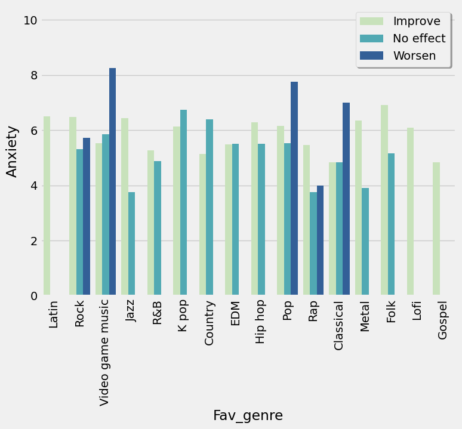

```python
plt.figure(figsize=(8,6))
sns.barplot(x=music['Fav_genre'], y=music['Anxiety'], hue=music['Music_effects'], errwidth=0, palette='YlGnBu')
plt.xticks(rotation=90)
plt.legend(shadow=True, loc='upper right')
plt.show()
```

#### Rock, Video Game Music, Pop, Rap, and Classical listeners have some level of Anxiety but Video Game Music listeners have highest Anxiety.

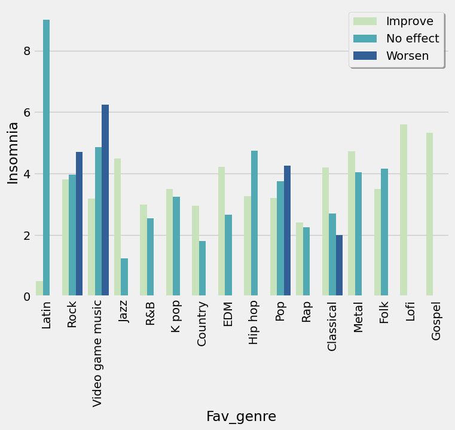

```python
plt.figure(figsize=(8,6))
sns.barplot(x=music['Fav_genre'], y=music['Insomnia'], hue=music['Music_effects'], errwidth=0, palette='YlGnBu')
plt.xticks(rotation=90)
plt.legend(shadow=True, loc='upper right')
plt.show()
```

#### Rock, Video Game Music, Pop, and Classical listeners have some level of Insomnia but Video Game Music listeners have highest Anxiety.

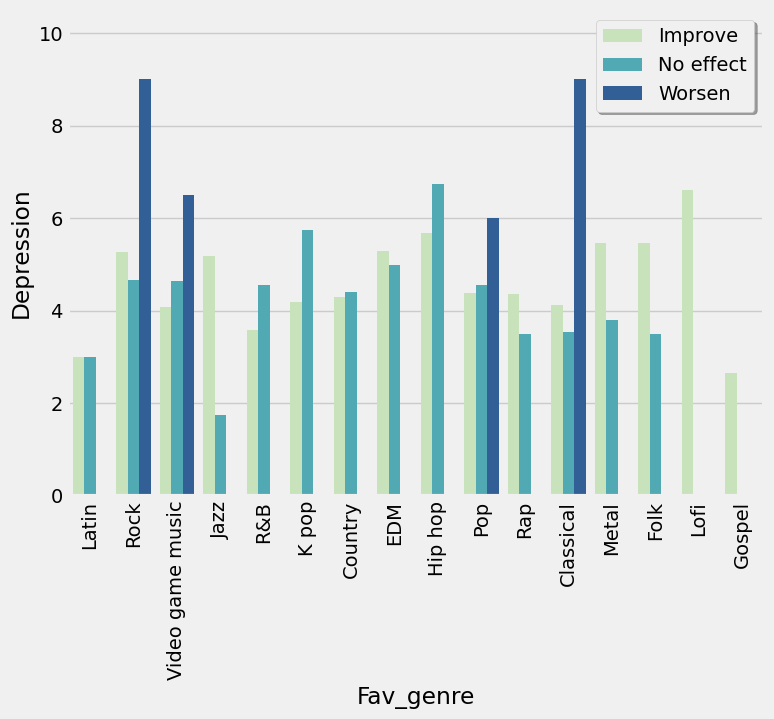

```python
plt.figure(figsize=(8,6))
sns.barplot(x=music['Fav_genre'], y=music['Depression'], hue=music['Music_effects'], errwidth=0, palette='YlGnBu')
plt.xticks(rotation=90)
plt.legend(shadow=True, loc='upper right')
plt.show()
```

#### Rock, Video Game Music, Pop, and Classical listeners have high level of Depression.

### From above analysis it is very clear that Music works in both ways. It helps in our mental condition but in some cases it worsen our situation too.

### In atmost cases, Rock, Video Game Music, Pop, and Classical had negative impacts on mental health of listeners.

[figure not shown]

```python
import matplotlib.patches as mpatches

i = 11

r_dist = []
s_dist = []
n_dist = []
vf_dist = []

while i != 27:
    freq_dist = music.iloc[:, i].value_counts().sort_index(ascending=True).tolist()
    r_dist.append(freq_dist[0])
    s_dist.append(freq_dist[1])
    n_dist.append(freq_dist[2])
    vf_dist.append(freq_dist[3])

    i+=1

fig, ax = plt.subplots()

for i in range (0, 16):

    ax.bar(i, n_dist[i], label='Never', bottom=vf_dist[i] + s_dist[i] + r_dist[i], color = "#7fcdbb")
    ax.bar(i, r_dist[i], label='Rare', bottom = vf_dist[i] + s_dist[i], color = "#41b6c4")
    ax.bar(i, s_dist[i], label='Sometimes', bottom = vf_dist[i], color = "#1d91c0")
    ax.bar(i, vf_dist[i], label='Very frequently', color = "#225ea8")


ax.set_title('(In Depth) Genres by Popularity')
ax.set_xticks([0,1,2,3,4,5,6,7,8,9,10,11,12,13,14,15])
ax.set_xticklabels(g_all)
plt.xticks(rotation = 45)

patch1 = mpatches.Patch(color='#7fcdbb', label='Never')
patch2 = mpatches.Patch(color='#41b6c4', label='Rarely')
patch3 = mpatches.Patch(color='#1d91c0', label='Sometimes')
patch4 = mpatches.Patch(color='#225ea8', label='Very frequently')

plt.legend(handles=[patch1, patch2, patch3, patch4], bbox_to_anchor=(1.05, 1.0), loc='upper left', shadow="true");
```

```python
abc = music.iloc[:, i].value_counts().sort_index(ascending=True)
```

```python
abc[0]
```

```
535
```

```python
g_all
```

```
array(['Classical', 'Country', 'EDM', 'Folk', 'Gospel', 'Hip hop', 'Jazz',
       'K pop', 'Latin', 'Lofi', 'Metal', 'Pop', 'R&B', 'Rap', 'Rock',
       'Video game music'], dtype=object)
```

#### Music can be an effective tool in regulating mental health conditions. While some genres may worsen situations, others definitely improve mental health conditions.

#### Overall, 75% of participants reported an improvement in mental health symptoms listening to music, 23% had no effect, and 2% thought it worsened symptoms. Self reported scores showed that the majority of participants had more severe symptoms related to anxiety and depression, with less severe score for insomnia, and OCD being the least prevelent illness.

#### Majority of the participants listened to music between 1-4 hours per day and saw improvement in their mental health symptoms.

#### Only participants under 40 reported worsening effects listening to music. With larger number of older participants would allow us to see if this is only for this sample or if music doesnt affect people over 40 in a negative way.

#### Looking at participants favorite genre of music there were only 5 were participants reported worsening effects. It would be intersting with a greater sample size to see how different genres of music may affect mental health and if changing what music participants are listening to alters the effect it has. All genres had participants that reported improvement in mental health symptoms showing it depends on the person how the type of music effects them.

#### Music seems to have a positive correlation to improving mental health symptoms. For future studies, more participants are needed that are over 25 in order to get a clear analysis of how music effects the age range of 30-80. It might be intersting to see the effect music has on certain times of the day such as first thing in the morning or right before bed. Another study idea could be when certain stressors are present to listen to one song and record the immediate and if any lasting effects that has on symptoms and mood.